# Clean the GSB dataset

septiembre 11, 2019

```r
knitr::opts_chunk$set(
  echo = TRUE,
  message = FALSE,
  warning = FALSE
)

# Load packages
suppressPackageStartupMessages({
  library(startR)
  library(here)
  library(broom)
  library(stargazer)
  library(ggrepel)
  library(tidyverse)
})

# Read the data
gsb_data <- read.csv(file = here("data", "biometrics.csv"),
                     stringsAsFactors = F)

# Set defaults

update_geom_defaults(geom = "point",
                     list(shape = 21,
                          color = "black",
                          size = 3))

update_geom_defaults(geom = "density",
                     list(fill = "steelblue",
                          alpha = 0.5))

update_geom_defaults(geom = "smooth",
                     list(method = "lm",
                          linetype = "dashed",
                          color = "black",
                          size = 1))

theme_set(ggtheme_plot())

ggplot <- function(...) ggplot2::ggplot(...) + scale_fill_brewer(palette = "Set1")
```

This document contains the analyses of biometric data for Giant Sea Bass. We will first focus on the fish biometrics and all their relationships. We will then go to otolith biometrics. Then we’ll combine these two.

# Body measurements

Body biometrics makes reference to the following variables:

- `f_w` for fish weight, in kg
- `f_tl` for fish Total Length, in cm
- `f_sl` for fish Standard Length, in cm
- `f_hl` for fish head length, in cm
- `f_condition` for the condition of the fish

## Length - length relationships

### SL 2 TL

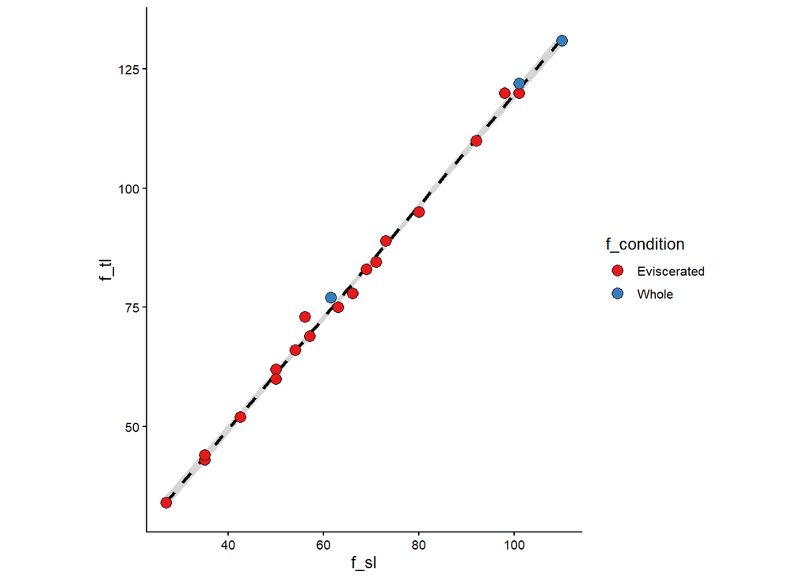

```r
gsb_data %>%
  select(f_tl, f_sl, f_condition, obs) %>%
  drop_na(f_tl, f_sl) %>%
  ggplot(mapping = aes(x = f_sl, y = f_tl)) +
  geom_smooth(method = "lm") +
  geom_point(aes(fill = f_condition)) +
  geom_text_repel(aes(label = obs)) +
  coord_equal()
```

## Head - length relationships

Sometimes we can only sample a head. What whas the size of the organism? Let’s try and do that.

### HL 2 SL

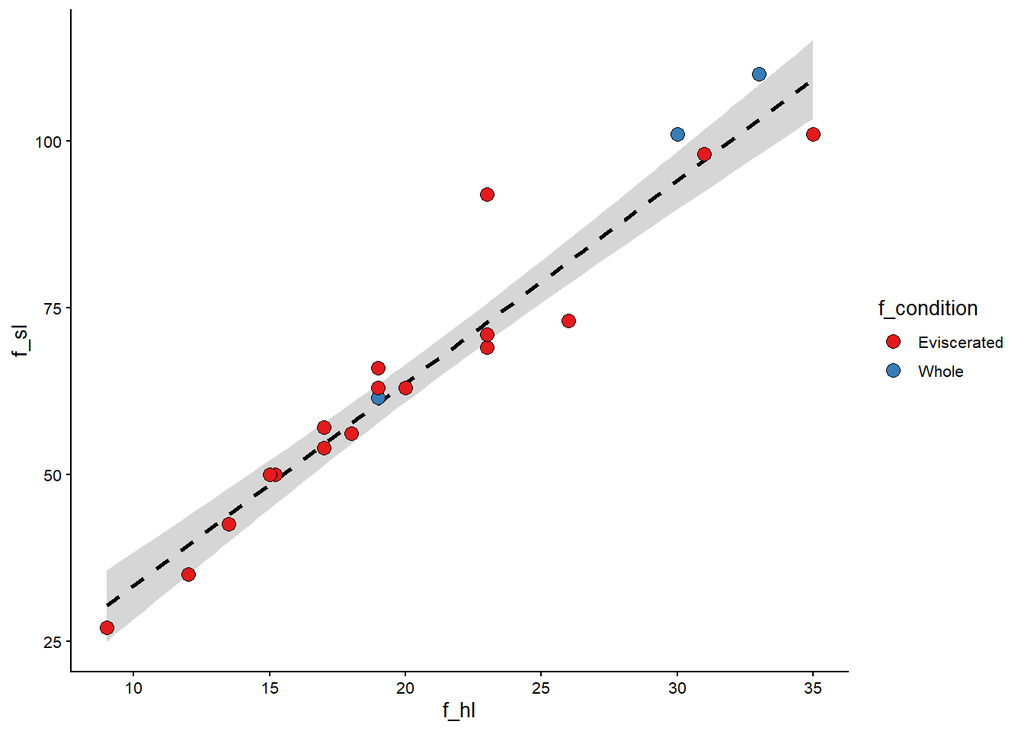

```r
gsb_data %>%
  select(f_hl, f_sl, f_condition, obs) %>%
  drop_na(f_hl, f_sl) %>%
  ggplot(mapping = aes(x = f_hl, y = f_sl)) +
  geom_smooth(method = "lm") +
  geom_point(aes(fill = f_condition)) +
  geom_text_repel(aes(label = obs))
```

### HL 2 TL

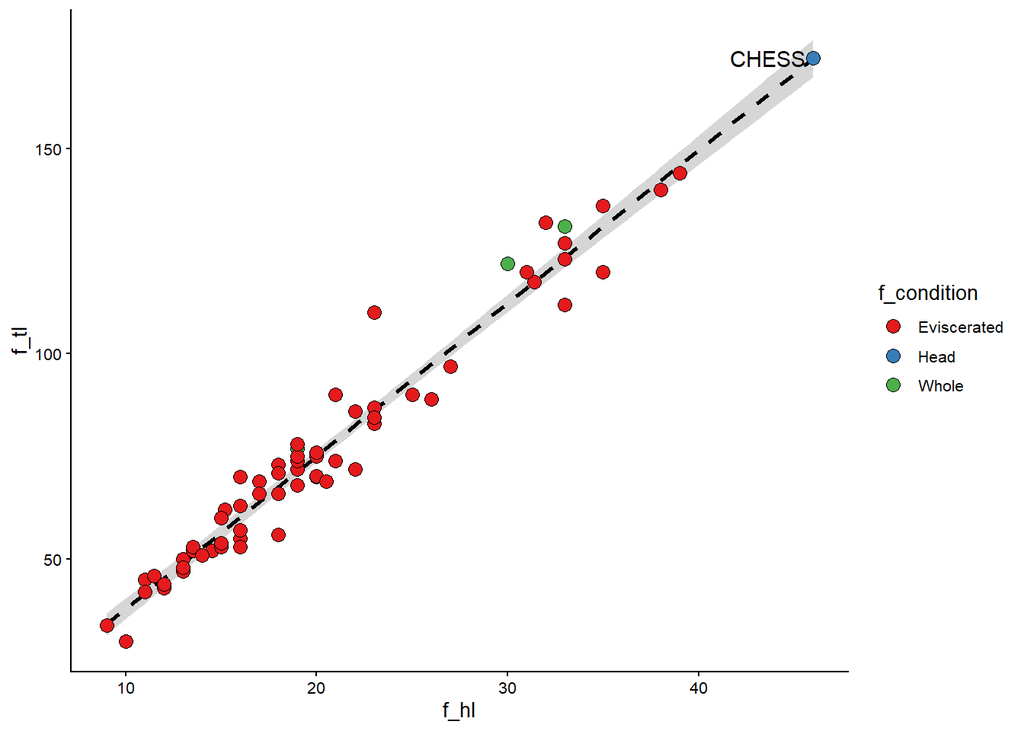

```r
gsb_data %>%
  select(f_hl, f_tl, f_condition, obs) %>%
  drop_na(f_hl, f_tl) %>%
  ggplot(mapping = aes(x = f_hl, y = f_tl)) +
  geom_smooth(method = "lm") +
  geom_point(aes(fill = f_condition)) +
  geom_text_repel(aes(label = obs))
```

## Weight - length relationships

### SL 2 W

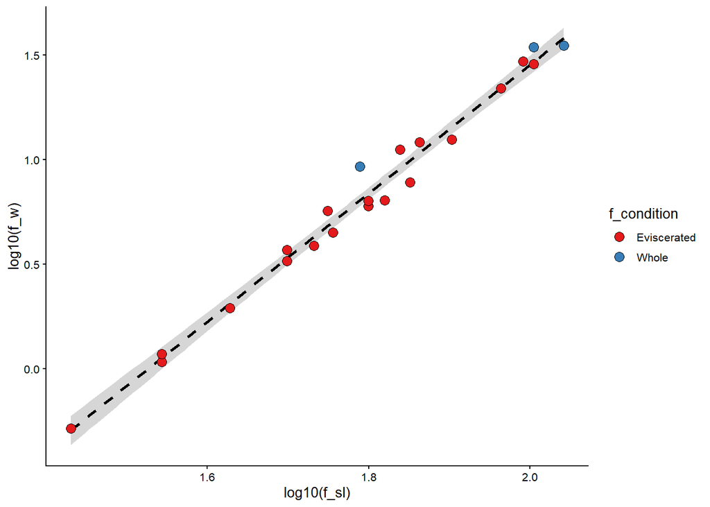

```r
gsb_data %>%
  select(f_w, f_sl, f_condition, obs) %>%
  drop_na(f_w, f_sl) %>%
  ggplot(mapping = aes(x = log10(f_sl), y = log10(f_w))) +
  geom_smooth(method = "lm")+
  geom_point(aes(fill = f_condition)) +
  geom_text_repel(aes(label = obs))
```

### TL 2 W

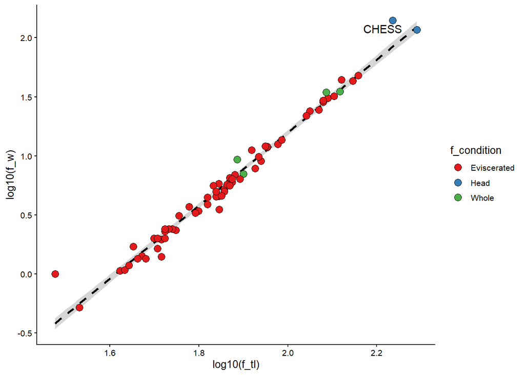

```r
gsb_data %>%
  select(f_w, f_tl, f_condition, obs) %>%
  drop_na(f_w, f_tl) %>%
  ggplot(mapping = aes(x = log10(f_tl), y = log10(f_w))) +
  geom_smooth(method = "lm")+
  geom_point(aes(fill = f_condition)) +
  geom_text_repel(aes(label = obs))
```

### HL 2 W

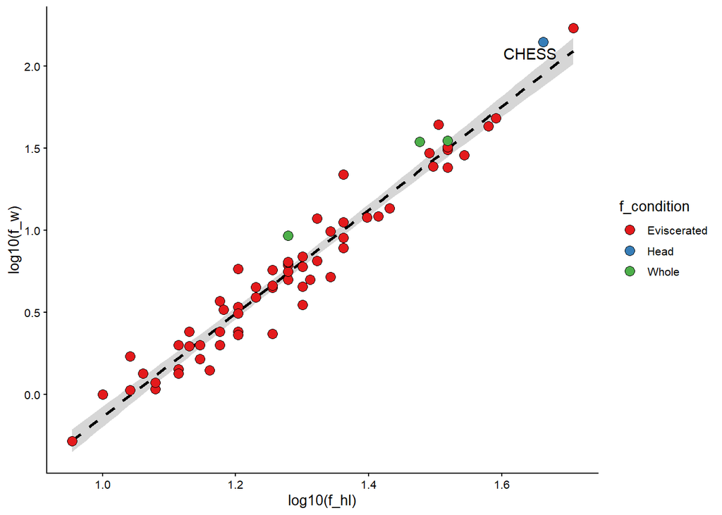

```r
gsb_data %>%
  select(f_w, f_hl, f_condition, obs) %>%
  drop_na(f_w, f_hl) %>%
  ggplot(mapping = aes(x = log10(f_hl), y = log10(f_w))) +
  geom_smooth(method = "lm")+
  geom_point(aes(fill = f_condition)) +
  geom_text_repel(aes(label = obs))
```

## Estimate all fish parameters

```r
# Function to fit the model
fit_model <- function(x, data) {
  # f <- as.formula(x)
  lm(formula = f, data = data)
}

# Function to plot the residuals
res_plot <- function(x, title) {
  d <- tibble(residuals = x$residuals)

  ggplot(data = d, mapping = aes(x = residuals)) +
    geom_density() +
    ggtitle(title)
}

# Filter the data
gsb_data_filtered <-
  gsb_data %>%
  filter(!f_condition == "HEAD")

# Fit the models
length_models <- tibble(model_name = c("SL2TL",
                                       "HL2SL",
                                       "HL2TL",
                                       "SL2TW",
                                       "TL2TW",
                                       "HL2TW"),
                        formula = c("f_tl ~ f_sl",
                                    "f_sl ~ f_hl",
                                    "f_tl ~ f_hl",
                                    "log10(f_w) ~ log10(f_sl)",
                                    "log10(f_w) ~ log10(f_tl)",
                                    "log10(f_w) ~ log10(f_hl)")) %>%
  mutate(formula2 = map(formula, as.formula)) %>%
  separate(formula, into = c("dep_var", "exp_var"), sep = "~", remove = F) %>%
  mutate(model = map(formula2, ~lm(., data = gsb_data_filtered), gsb_data_filtered = gsb_data_filtered),
         res_plot = map2(.x = model, .y = model_name, .f = res_plot),
         dep_var = str_trim(dep_var),
         dep_var = str_remove_all(dep_var, "f_"))
```

## Fish parameter results

### Table

```r
stargazer(length_models$model,
          single.row = T,
          dep.var.labels.include = T,
          dep.var.labels = length_models$dep_var,
          type = "html",
          out = "test.html")
```

|  | *Dependent variable:* |  |  |  |  |  |
| --- | --- | --- | --- | --- | --- | --- |
|  | tl | sl | tl | log10(w) |  |  |
|  | (1) | (2) | (3) | (4) | (5) | (6) |
| f_sl | 1.171*** (0.014) |  |  |  |  |  |
| f_hl |  | 3.038*** (0.179) | 3.720*** (0.087) |  |  |  |
| log10(f_sl) |  |  |  | 3.072*** (0.083) |  |  |
| log10(f_tl) |  |  |  |  | 3.093*** (0.053) |  |
| log10(f_hl) |  |  |  |  |  | 3.150*** (0.091) |
| Constant | 2.644** (1.014) | 2.924 (4.016) | 0.724 (2.011) | -4.690*** (0.151) | -4.990*** (0.100) | -3.287*** (0.119) |
| Observations | 23 | 22 | 69 | 23 | 71 | 68 |
| R<sup>2</sup> | 0.997 | 0.935 | 0.964 | 0.985 | 0.980 | 0.948 |
| Adjusted R<sup>2</sup> | 0.997 | 0.932 | 0.964 | 0.984 | 0.980 | 0.947 |
| Residual Std. Error | 1.578 (df = 21) | 6.308 (df = 20) | 6.120 (df = 67) | 0.064 (df = 21) | 0.078 (df = 69) | 0.125 (df = 66) |
| F Statistic | 6,824.978*** (df = 1; 21) | 287.555*** (df = 1; 20) | 1,814.369*** (df = 1; 67) | 1,362.457*** (df = 1; 21) | 3,399.690*** (df = 1; 69) | 1,203.656*** (df = 1; 66) |
| *Note:* | p<0.1; p<0.05; p<0.01 |  |  |  |  |  |

### Residual plots

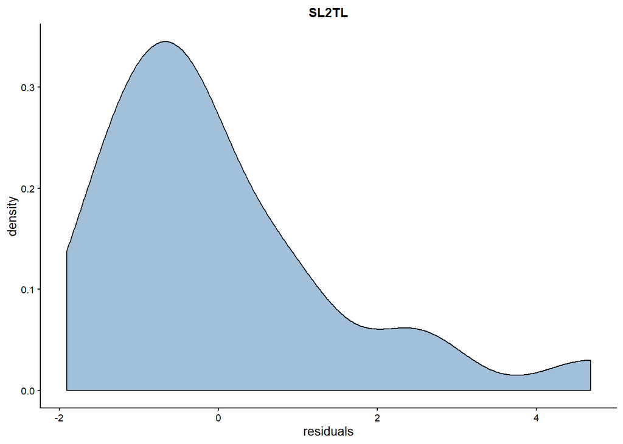

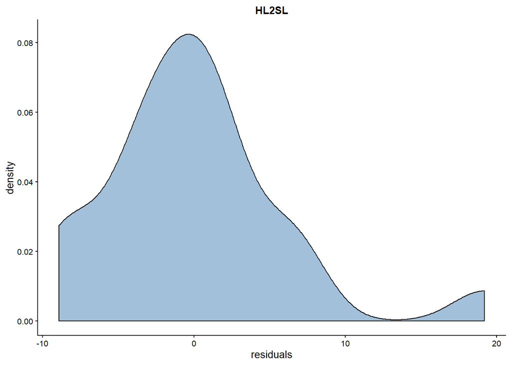

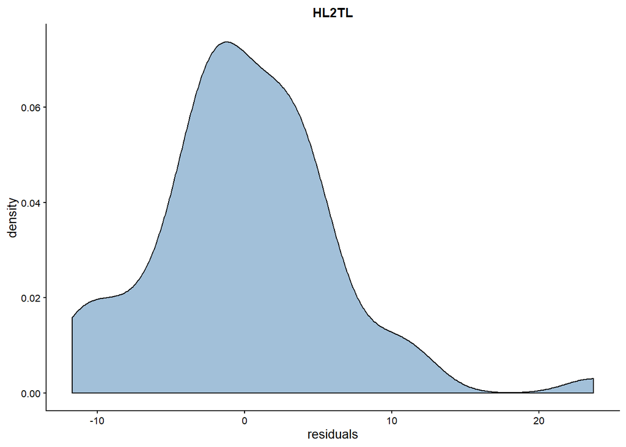

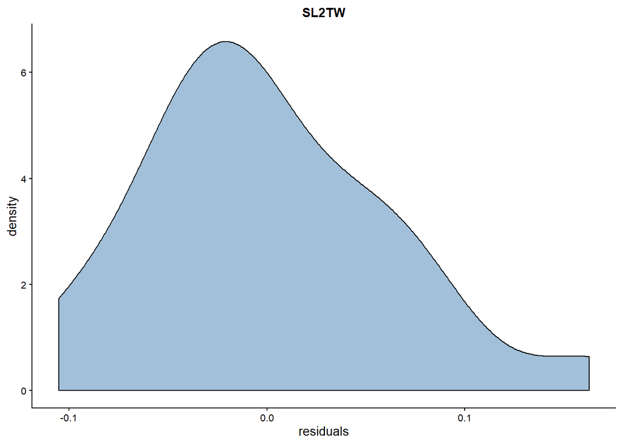

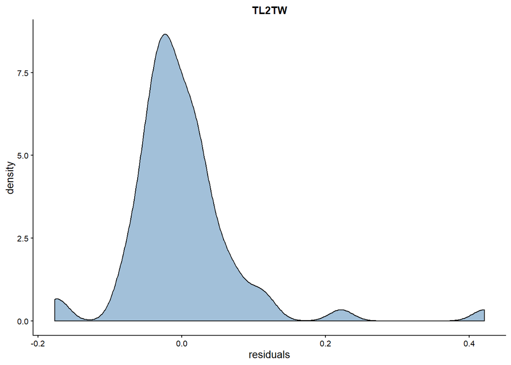

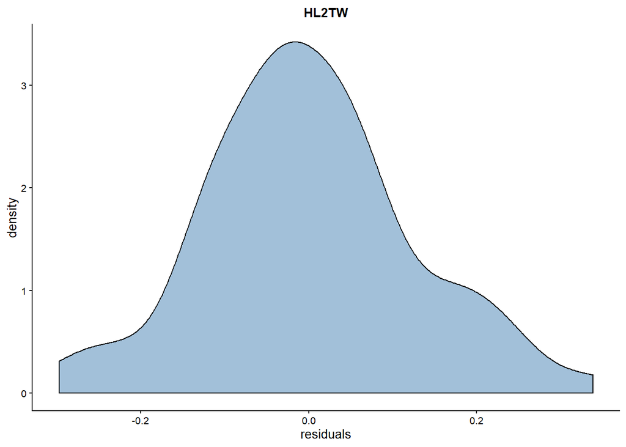

```r
length_models$res_plot
```

# Otolith measurements

- `o_de` for otolith depth
- `o_le` for otolith length
- `o_wi` for otolith width
- `o_td` for otolith total depth
- `o_we` for otolith weight

Additionally

- `o_side` to specify the side of the hade from where the otolith chame
- `o_condition` to specify if it was complete or broken
- `o_obs` for any observations

## DE 2 TD

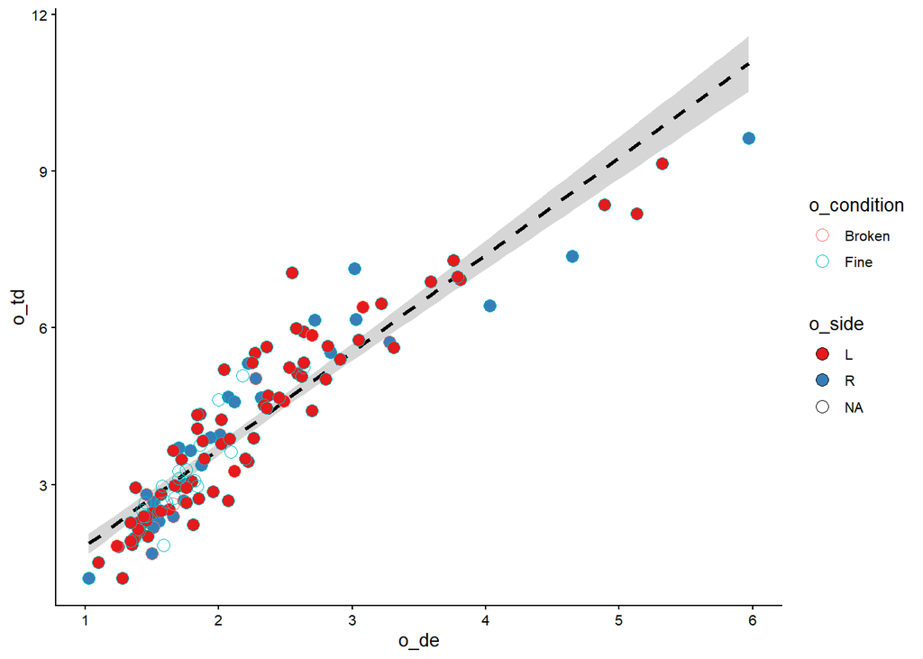

```r
gsb_data %>%
  select(o_de, o_td, o_side, o_condition) %>%
  drop_na(o_de, o_td) %>%
  ggplot(aes(x = o_de, y = o_td)) +
  geom_smooth(method = "lm") +
  geom_point(aes(fill = o_side, color = o_condition))
```

## DE 2 LE

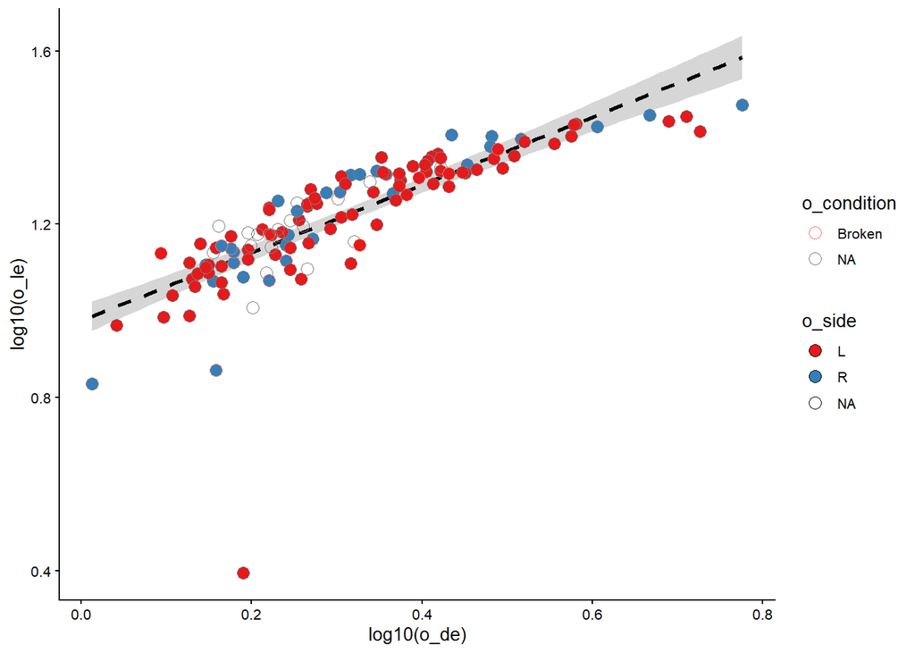

```r
gsb_data %>%
  select(o_de, o_le, o_side, o_condition) %>%
  drop_na(o_de, o_le) %>%
  mutate(o_condition = ifelse(o_condition == "Fine", NA, o_condition)) %>%
  ggplot(aes(x = log10(o_de), y = log10(o_le))) +
  geom_smooth(method = "lm") +
  geom_point(aes(fill = o_side, color = o_condition))
```

## DE 2 WI

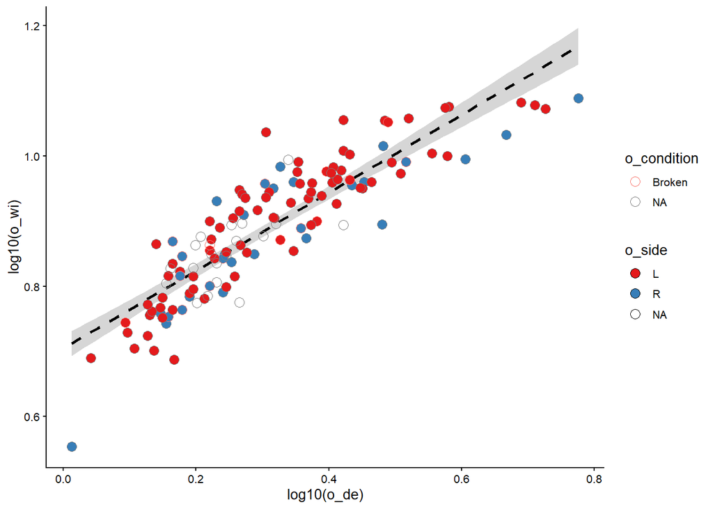

```r
gsb_data %>%
  select(o_de, o_wi, o_side, o_condition) %>%
  drop_na(o_de, o_wi) %>%
  mutate(o_condition = ifelse(o_condition == "Fine", NA, o_condition)) %>%
  ggplot(aes(x = log10(o_de), y = log10(o_wi))) +
  geom_smooth(method = "lm") +
  geom_point(aes(fill = o_side, color = o_condition))
```

## DE 2 WE

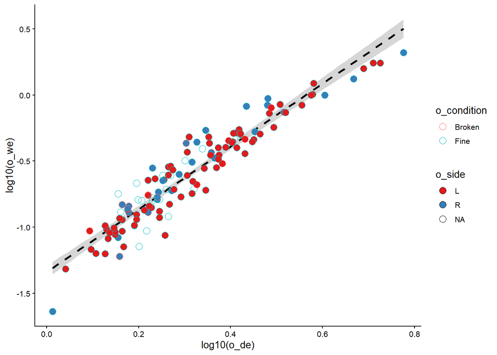

```r
gsb_data %>%
  select(o_de, o_we, o_side, o_condition) %>%
  drop_na(o_de, o_we) %>%
  ggplot(aes(x = log10(o_de), y = log10(o_we))) +
  geom_smooth(method = "lm") +
  geom_point(aes(fill = o_side, color = o_condition))
```

[figure not shown]

```r
gsb_data %>%
  select(starts_with("o_"), age, age2) %>%
  ggplot()
```

# Body - Otolith relationships